# Understanding MCMC and Traceplots (理解 MCMC 与轨迹图)

Antigravity

2026-06-13

# Introduction to MCMC and Traceplots (MCMC 与轨迹图简介)

Imagine you are looking at a map of a mountainous island covered in thick fog. You want to find where the highest peaks are, but you cannot see the whole island at once. You can only stand on a spot, feel the slope under your feet, and make a decision on where to step next.

This is what **Markov Chain Monte Carlo (马尔可夫链蒙特卡罗, MCMC)** does! * The **island** is the **probability distribution (概率分布)** of the parameters we want to estimate. * The **elevation (海拔)** at any spot is the likelihood of those parameter values. * The **foggy explorer** is our MCMC sampler, taking step after step to explore the landscape.

Over time, the explorer will spend more time walking around the peaks (areas of high probability) and less time in the low valleys (areas of low probability). If we record the explorer’s position at every step, we get a long sequence of locations. This sequence is a **Markov Chain (马尔可夫链)**.

A **Traceplot (轨迹图)** is simply a timeline of where the explorer stood. The horizontal axis (X-axis) shows the **iteration number (迭代次数)** (time steps), and the vertical axis (Y-axis) shows the **parameter value (参数值)** (e.g., the longitude or latitude on the island).

# What does a Traceplot look like? (轨迹图长什么样？)

When we look at a Traceplot (轨迹图), we want to see if the explorer has successfully found the peaks and is bouncing around them in a stable way. We check two main things:

1. **Convergence (收敛)**: Has the explorer reached the peak area? If yes, the traceplot will fluctuate around a stable average value. If it is still climbing up or down, it has not converged yet.
2. **Mixing (混合)**: Is the explorer moving quickly and freely, or taking tiny, sticky steps? Good mixing means the chain moves up and down rapidly, looking like a “fuzzy caterpillar” (毛毛虫) or a “thick lawn” (茂密的草坪). Bad mixing looks like a slow, wavy snake.

# Simulation in R (R 语言模拟)

Below, we write a simple **Metropolis-Hastings Algorithm (梅特罗波利斯-海斯廷斯算法)** from scratch to sample from a target distribution (a normal distribution) and plot the traceplots to see good and bad behaviors.

```r
# Load library for visualization
library(ggplot2)

# If you want to use Chinese in plots, uncomment the lines below to avoid display issues:
# 如果你想在图表中使用中文，请取消下面两行的注释以避免显示乱码（豆腐块）问题：
# if (!requireNamespace("showtext", quietly = TRUE)) install.packages("showtext")
# library(showtext)
# showtext_auto()
```

## 1. Defining the MCMC Sampler (定义 MCMC 采样器)

We will implement a simple function that attempts to sample from a **Target Distribution (目标分布)**: a Normal Distribution with a mean of 5 and a standard deviation of 1.

```r
# Metropolis-Hastings MCMC Sampler
# standard_deviation_proposal: control how far the explorer can jump at each step
run_mcmc <- function(iterations, start_value, sd_proposal) {
  # Initialize vector to store the samples (parameter values)
  chain <- numeric(iterations)
  chain[1] <- start_value

  # Target distribution density function (log scale for numerical stability)
  # 目标分布概率密度（对数尺度以保证数值稳定性）
  target_log_density <- function(x) {
    dnorm(x, mean = 5, sd = 1, log = TRUE)
  }

  accepted_steps <- 0

  for (t in 2:iterations) {
    current_value <- chain[t - 1]

    # 1. Propose a new value using a Normal Proposal Distribution (提议分布)
    proposed_value <- rnorm(1, mean = current_value, sd = sd_proposal)

    # 2. Calculate Acceptance Probability (接受概率)
    log_alpha <- target_log_density(proposed_value) - target_log_density(current_value)
    alpha <- exp(log_alpha)

    # 3. Accept or reject the proposal (接受或拒绝候选值)
    if (runif(1) < alpha) {
      chain[t] <- proposed_value
      accepted_steps <- accepted_steps + 1
    } else {
      chain[t] <- current_value
    }
  }

  # Calculate overall acceptance rate (计算接受率)
  acceptance_rate <- accepted_steps / (iterations - 1)

  return(list(chain = chain, acceptance_rate = acceptance_rate))
}
```

## 2. Running the Simulations (运行模拟)

We will run three simulations with different step sizes (standard deviations of the proposal distribution) to see how they impact the traceplots.

```r
iterations <- 2000
start_value <- -10  # Start far away from the target mean (5) to see convergence

# Case A: Good Proposal Step Size (合适的步长 - Good Mixing)
mcmc_good <- run_mcmc(iterations, start_value, sd_proposal = 0.5)

# Case B: Too Small Proposal Step Size (步长太小 - Bad Mixing, slow exploration)
mcmc_small <- run_mcmc(iterations, start_value, sd_proposal = 0.02)

# Case C: Too Large Proposal Step Size (步长太大 - Stuck, low acceptance rate)
mcmc_large <- run_mcmc(iterations, start_value, sd_proposal = 10)
```

## 3. Visualizing Traceplots (绘制轨迹图)

Let’s plot the traceplots and analyze what they show us.

### Case A: Good Mixing (好的混合 - The “Fuzzy Caterpillar”)

When the step size is just right, the chain quickly moves from its starting point (-10) to the target area (around 5) and fluctuates rapidly.

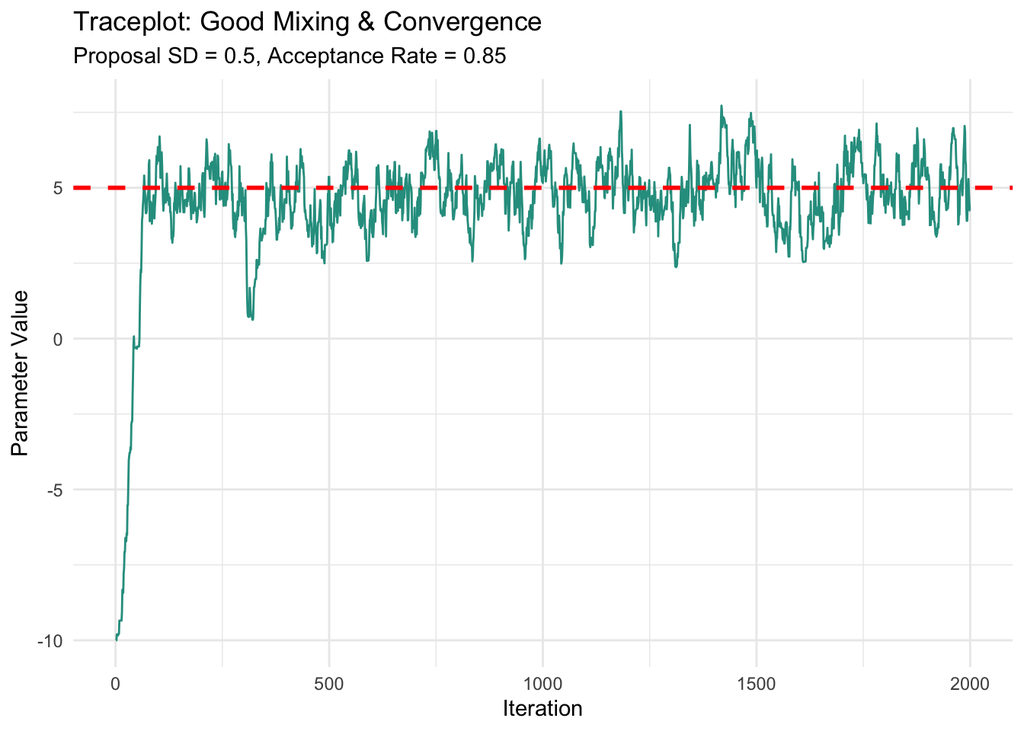

```r
df_good <- data.frame(
  Iteration = 1:iterations,
  Value = mcmc_good$chain
)

ggplot(df_good, aes(x = Iteration, y = Value)) +
  geom_line(color = "#2a9d8f") +
  geom_hline(yintercept = 5, linetype = "dashed", color = "red", linewidth = 1) +
  labs(
    title = "Traceplot: Good Mixing & Convergence",
    subtitle = paste("Proposal SD = 0.5, Acceptance Rate =", round(mcmc_good$acceptance_rate, 2)),
    x = "Iteration",
    y = "Parameter Value"
  ) +
  theme_minimal()
```

- **Burn-in Period (预热期/烧入期)**: Notice the first ~100 steps where the chain climbs from -10 up to 5. We usually throw these initial steps away because they don’t represent the target distribution.
- **Fuzzy Caterpillar (毛毛虫)**: Once it reaches 5, the chain moves up and down rapidly, filling the space. This is a healthy traceplot!

### Case B: Too Small Steps (步长太小 - Slow Exploration)

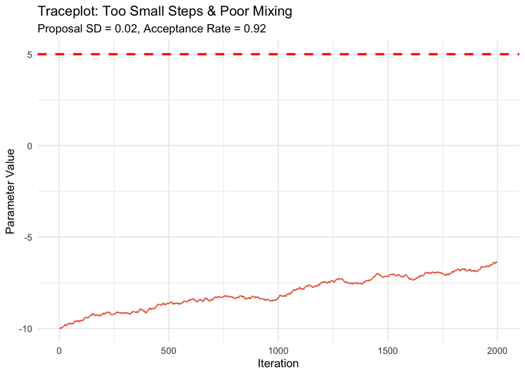

```r
df_small <- data.frame(
  Iteration = 1:iterations,
  Value = mcmc_small$chain
)

ggplot(df_small, aes(x = Iteration, y = Value)) +
  geom_line(color = "#e76f51") +
  geom_hline(yintercept = 5, linetype = "dashed", color = "red", linewidth = 1) +
  labs(
    title = "Traceplot: Too Small Steps & Poor Mixing",
    subtitle = paste("Proposal SD = 0.02, Acceptance Rate =", round(mcmc_small$acceptance_rate, 2)),
    x = "Iteration",
    y = "Parameter Value"
  ) +
  theme_minimal()
```

- **Observation (观察)**: The chain is highly **autocorrelated (自相关的)**—each step is almost identical to the previous one. The traceplot looks smooth and wavy. This is bad mixing!

### Case C: Too Large Steps (步长太大 - High Rejection)

When the step size is too large, the explorer tries to make giant leaps. Most of these leaps land in low-probability regions, so they get rejected, and the explorer stays in the same spot for many steps.

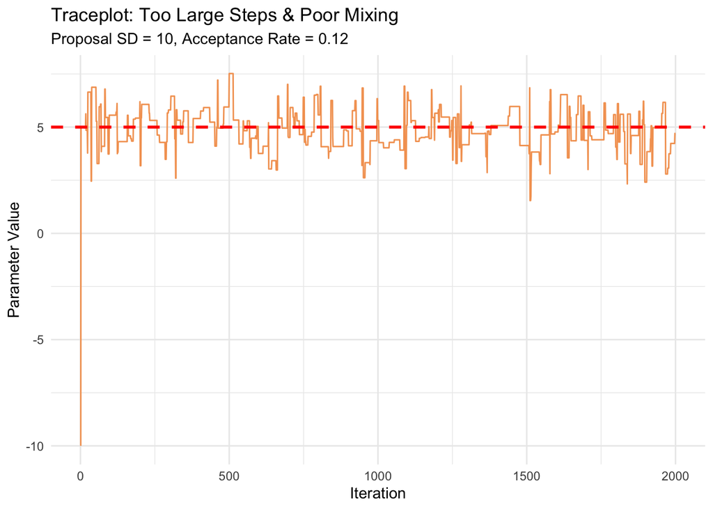

```r
df_large <- data.frame(
  Iteration = 1:iterations,
  Value = mcmc_large$chain
)

ggplot(df_large, aes(x = Iteration, y = Value)) +
  geom_line(color = "#f4a261") +
  geom_hline(yintercept = 5, linetype = "dashed", color = "red", linewidth = 1) +
  labs(
    title = "Traceplot: Too Large Steps & Poor Mixing",
    subtitle = paste("Proposal SD = 10, Acceptance Rate =", round(mcmc_large$acceptance_rate, 2)),
    x = "Iteration",
    y = "Parameter Value"
  ) +
  theme_minimal()
```

- **Observation (观察)**: The traceplot looks like flat steps followed by sudden jumps. The acceptance rate is extremely low, meaning the chain is inefficient.

# 4. A Real-world Bayesian Example using `rstan` (使用 `rstan` 的实际贝叶斯例子)

Now, let’s look at how modern scientists run MCMC. They rarely write the sampler from scratch; instead, they use a highly powerful probabilistic programming language called **Stan** (via the **`rstan`** package in R).

### The Scenario (场景)

Imagine a high school physical education teacher wants to estimate the true average height ($\mu$) and standard deviation ($\sigma$) of all high school boys in the city. The teacher randomly measures **50 students** and gets their heights in centimeters.

We will simulate this data and use `rstan` to estimate the parameters $\mu$ and $\sigma$.

```r
# Load rstan
# 如果您没有安装 rstan，请取消下面这行的注释进行安装：
# if (!requireNamespace("rstan", quietly = TRUE)) install.packages("rstan")
library(rstan)

# For faster execution, run chains in parallel (多核并行加速)
options(mc.cores = parallel::detectCores())
# Avoid recompiling unchanged Stan code (避免重复编译)
rstan_options(auto_write = TRUE)

# 1. Simulate the data (模拟身高数据)
set.seed(42)
true_mean <- 170   # True average height (170cm)
true_sd <- 8       # True standard deviation (8cm)
N <- 50            # Sample size (50 students)

heights <- rnorm(N, mean = true_mean, sd = true_sd)
stan_data <- list(N = N, y = heights)
```

### 2. The Stan Model Code (编写 Stan 模型)

We write the Stan model as a string. It has three blocks: 1. `data`: Inputs we give to the model (sample size `N` and heights `y`). 2. `parameters`: The things we want to estimate (the mean `mu` and standard deviation `sigma`). 3. `model`: The priors (先验分布) and the likelihood (似然).

```r
stan_model_code <- "
data {
  int<lower=0> N;        // Number of observations (样本量)
  vector[N] y;           // Heights array (身高数据)
}
parameters {
  real mu;               // Population mean height (总体平均身高)
  real<lower=0> sigma;   // Population standard deviation (总体身高标准差)
}
model {
  // Priors: our educated guesses before seeing the data
  // 先验分布：我们在看到数据之前的合理猜测
  mu ~ normal(175, 10);
  sigma ~ cauchy(0, 5);

  // Likelihood: how the data is generated
  // 似然：数据是如何根据参数生成的
  y ~ normal(mu, sigma);
}
"
```

### 3. Running MCMC with Stan (使用 Stan 运行 MCMC)

By default, `rstan` runs **4 independent chains (4条独立的链/路径)**. This means 4 different “explorers” start from different random heights (e.g., one at 150cm, one at 190cm) and search for the peaks.

```r
# Fit the model (编译并拟合模型 - 这可能需要几十秒)
fit <- stan(
  model_code = stan_model_code,
  data = stan_data,
  iter = 2000,
  warmup = 1000, # Burn-in/Warmup iterations (预热/烧入迭代次数)
  chains = 4     # Number of independent chains (独立链数)
)
```

### 4. Viewing the Multichain Traceplot (查看多链轨迹图)

Let’s print the parameter estimates and look at the traceplot containing all 4 chains.

```r
# Print parameter estimates (输出参数估计值)
print(fit, pars = c("mu", "sigma"))
```

```
## Inference for Stan model: anon_model.
## 4 chains, each with iter=2000; warmup=1000; thin=1;
## post-warmup draws per chain=1000, total post-warmup draws=4000.
##
##         mean se_mean   sd   2.5%    25%    50%    75%  97.5% n_eff Rhat
## mu    169.83    0.02 1.32 167.23 168.95 169.82 170.70 172.36  3626    1
## sigma   9.29    0.02 0.94   7.67   8.62   9.21   9.88  11.29  3577    1
##
## Samples were drawn using NUTS(diag_e) at Sat Jun 13 01:10:43 2026.
## For each parameter, n_eff is a crude measure of effective sample size,
## and Rhat is the potential scale reduction factor on split chains (at
## convergence, Rhat=1).
```

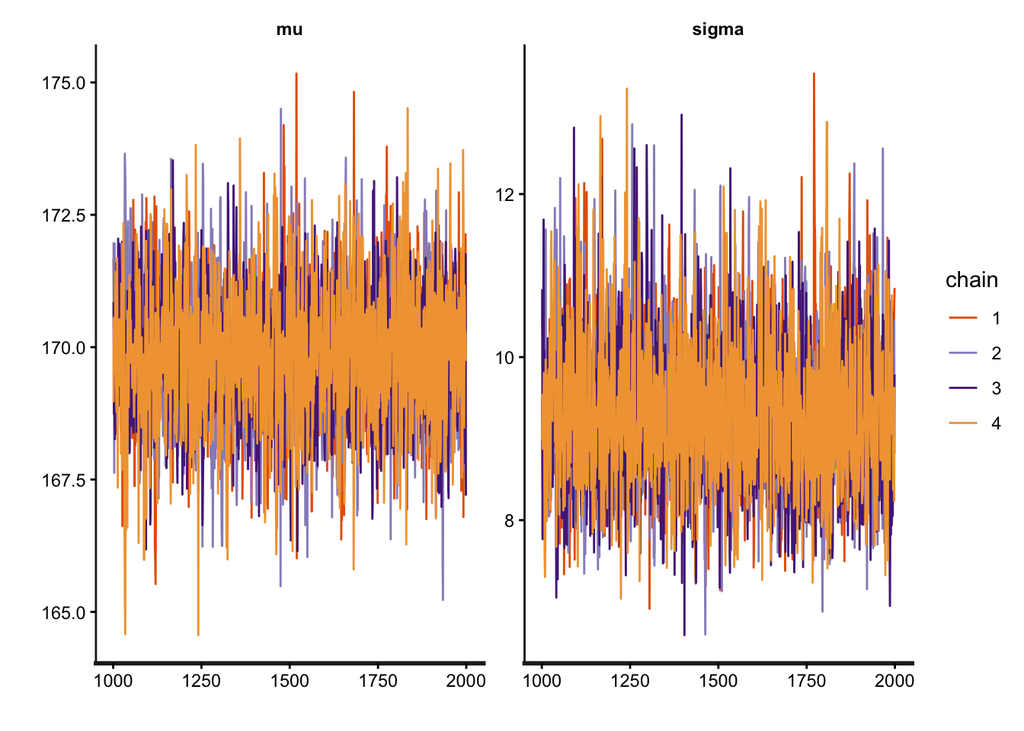

```r
# Plot traceplots for mu and sigma (绘制 mu 和 sigma 的轨迹图)
# Using rstan's built-in plotting function (which is built on ggplot2)
stan_trace(fit, pars = c("mu", "sigma"))
```

### 🔍 How to interpret the Stan Traceplot (如何解读 Stan 轨迹图)

1. **Overlapping Chains (链的重叠)**: You will see **4 different colored lines** (one for each chain).
   - **Good Sign (好现象)**: The 4 lines are completely mixed and overlaid on top of each other like a single multicolored fuzzy caterpillar. This means that no matter where the 4 explorers started, they all converged to the exact same mountain peaks!
   - **Bad Sign (坏现象)**: If the lines are separated or don’t overlap, it means some explorers are lost in different parts of the island, and the model has not converged.
2. **Warmup / Burn-in Exclusion (排除预热期)**: By default, `stan_trace()` only plots the iterations *after* the warmup period (from iteration 1001 to 2000). That is why the initial “climbing” phase is not shown; we are only looking at the stable exploration of the peaks.
3. **$\hat{R}$ Diagnostic (盖尔曼-鲁宾诊断值)**: In the print output, look at the `Rhat` column.
   - If `Rhat` is close to 1.00 (e.g., $< 1.05$), it mathematically confirms that the chains have converged.